# ADDF/RISE Machine Learning

Doug Tommet

2021-03-12

# Objective

The objective of this aim is to build models to predict cognitive decline over 36 months.

## Modeling

We used two approaches to predict cognitive decline.

1. The first was to model cognitive decline as a continuous outcome.
2. The second was to dichotomize it at -0.5, and then predict whether or not someone experienced cognitive decline.

## Models

The models used are:

1. Linear Regression
2. Gradient Boosted Models
3. Lasso and Elastic-net Regularized Regression
4. Random Forests
5. Neural Network
6. Support Vector Machines - linear kernel
7. Support Vector Machines - polynomial kernel
8. Multivariate adaptive regression splines
9. K-nearest neighbors

## Cross validation

The data was split into training (75%, n = 421) and testing (25%, n = 139) sets, stratified by cognitive slope. Cross-validtion was used in the training set to tune the machine learning models. Within the training set, 25 bootstrap samples were taken. The models were trained on the subjects selected by the bootstrap (analysis set (n = 421)) and evaluated on the unselected samples (assessment set (~37%, n = 145-166)).

## Covariates

The same sets of covariates were used as in the delirium prediction models. Missing values are single imputed using k-nearest neighbors.

# Table 1

These are the variables used in the machine learning analyses.

**Note:** 2021-03-13 - Added the variables Length of Stay and Dichotomized cognitive decline to the descriptive table, but they are not included in the analysis.

| **Characteristic** | **Training**, N = 421<sup>1</sup> | **Testing**, N = 139<sup>1</sup> | **Overall**, N = 560 |
| --- | --- | --- | --- |
| Outcome |  |  |  |
| Cognitive slope (36M) | -0.37 (0.18) | -0.37 (0.17) | -0.37 (0.18) |
| Cognitive slope > -0.5 | 339 / 421 (81%) | 110 / 139 (79%) | 449 / 560 (80%) |
| Demographics |  |  |  |
| Length of Stay | 5.25 (3.23) | 5.54 (3.74) | 5.32 (3.36) |
| Age | 76.8 (5.2) | 76.2 (5.0) | 76.6 (5.2) |
| Female | 257 / 421 (61%) | 69 / 139 (50%) | 326 / 560 (58%) |
| Education | 14.83 (2.90) | 15.40 (3.05) | 14.97 (2.95) |
| Nonwhite | 31 / 421 (7.4%) | 11 / 139 (7.9%) | 42 / 560 (7.5%) |
| English is second language | 27 / 421 (6.4%) | 11 / 139 (7.9%) | 38 / 560 (6.8%) |
| Lives alone | 128 / 421 (30%) | 39 / 139 (28%) | 167 / 560 (30%) |
| Health behaviors |  |  |  |
| Past smoker | 241 / 421 (57%) | 71 / 139 (51%) | 312 / 560 (56%) |
| Current smoker | 19 / 421 (4.5%) | 7 / 139 (5.0%) | 26 / 560 (4.6%) |
| Alcohol > 5/week | 77 / 418 (18%) | 29 / 136 (21%) | 106 / 554 (19%) |
| Missing | 3 | 3 | 6 |
| Health status |  |  |  |
| ADL (any) | 31 / 421 (7.4%) | 11 / 139 (7.9%) | 42 / 560 (7.5%) |
| IADL (any) | 108 / 421 (26%) | 44 / 139 (32%) | 152 / 560 (27%) |
| IADL cognitive (any) | 21 / 421 (5.0%) | 6 / 139 (4.3%) | 27 / 560 (4.8%) |
| Hearing impairment | 137 / 420 (33%) | 45 / 139 (32%) | 182 / 559 (33%) |
| Missing | 1 | 0 | 1 |
| Fraility - Weight Loss | 22 / 355 (6.2%) | 10 / 117 (8.5%) | 32 / 472 (6.8%) |
| Missing | 66 | 22 | 88 |
| Fraility - Low Grip Strength | 208 / 379 (55%) | 59 / 122 (48%) | 267 / 501 (53%) |
| Missing | 42 | 17 | 59 |
| Fraility - Slow Timed Walk | 195 / 379 (51%) | 65 / 121 (54%) | 260 / 500 (52%) |
| Missing | 42 | 18 | 60 |
| Depression (GDS 15) | 2.44 (2.44) | 2.55 (2.74) | 2.47 (2.52) |
| Missing | 2 | 0 | 2 |

[output cut: 61 more lines]

<sup>*1*</sup> Statistics presented: mean (SD); n / N (%)

# Results

## Continuous outcome models

This is the evaluation of the models in the testing set.

Model performance

| Model | RMSE | RMSE improvement (%) | R2 | R2 improvement (%) |
| --- | --- | --- | --- | --- |
| Linear Regression | 0.165 | 0.00 | 0.15 | 0.0 |
| Regularization Regression | 0.146 | 11.29 | 0.31 | 115.4 |
| Multivariate Adaptive Regression Splines | 0.148 | 10.12 | 0.26 | 75.9 |
| Random Forest | 0.153 | 6.94 | 0.20 | 34.4 |
| Gradient Boosted Model | 0.170 | −3.29 | 0.05 | −66.8 |
| Neural Network | 0.198 | −20.46 | 0.08 | −46.6 |
| K-Nearest Neighbor | 0.166 | −0.99 | 0.09 | −40.9 |

Figure of observed versus predicted slopes.

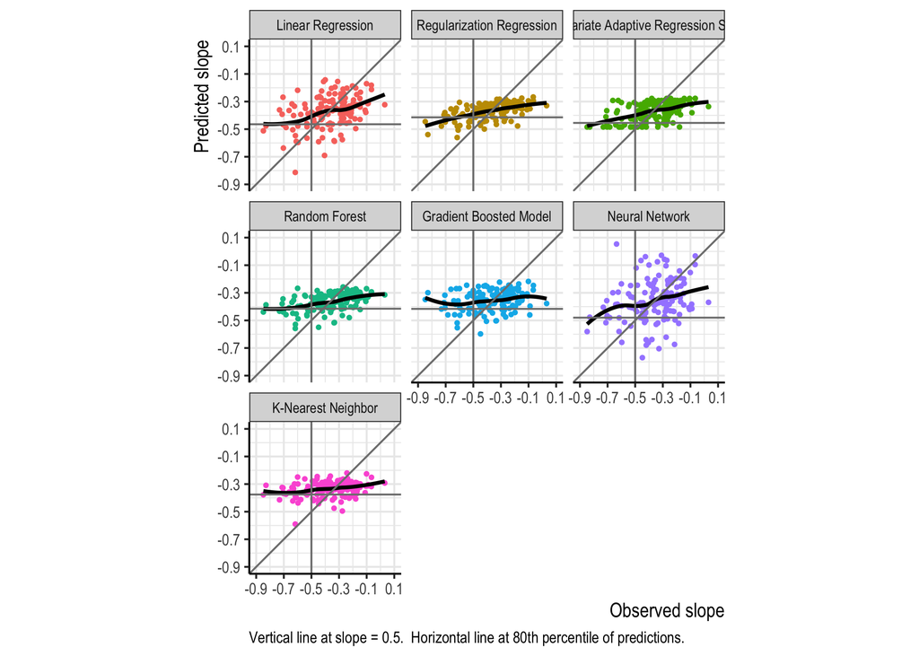

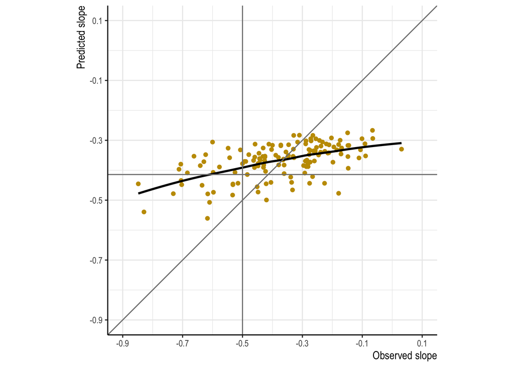

## Dichotomous outcome models

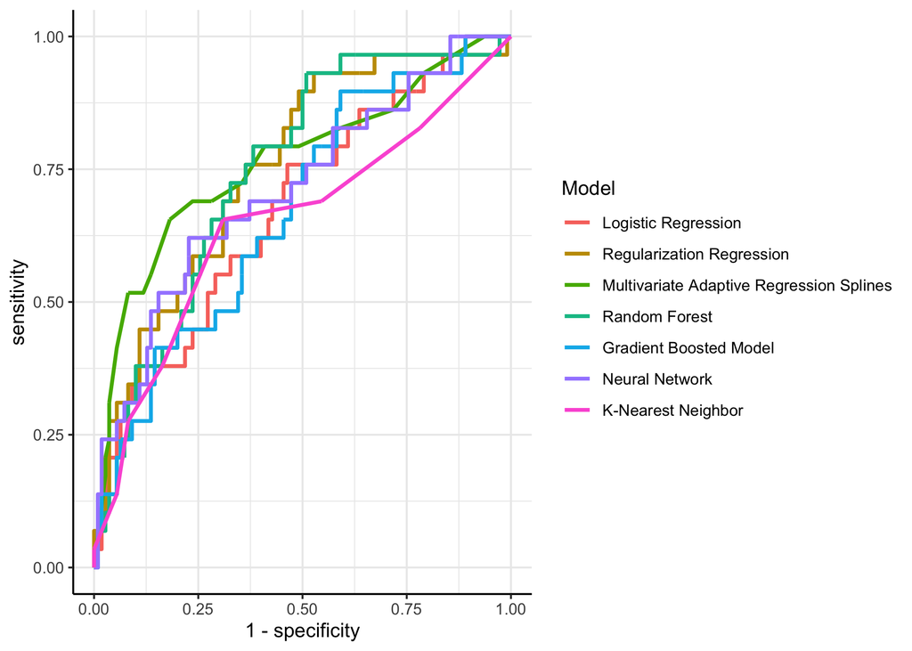

The predicted probability of having cognitive decline was dichotomized at the 20th percentile to match the prevalence of cognitive decline.

Cross-tab table for observed versus predicted cognitive decline.

True Cognitive Decline vs Predicted Decline

| Model | True Positive | False Negative | False Positive | True Negative |
| --- | --- | --- | --- | --- |
| Logistic Regression | 11 | 18 | 16 | 94 |
| Regularization Regression | 13 | 16 | 14 | 96 |
| Multivariate Adaptive Regression Splines | 15 | 14 | 9 | 101 |
| Random Forest | 11 | 18 | 16 | 94 |
| Gradient Boosted Model | 11 | 18 | 16 | 94 |
| Neural Network | 12 | 17 | 15 | 95 |
| K-Nearest Neighbor | 8 | 21 | 9 | 101 |

Summary statistics from cross-tab tables.

Model summary statistics

| Model | AUC | Sens | Spec | PPV | NPV | F1 | Youden's J | Kappa | Balanced Accuracy |
| --- | --- | --- | --- | --- | --- | --- | --- | --- | --- |
| Logistic Regression | 0.68 | 0.38 | 0.85 | 0.41 | 0.84 | 0.39 | 0.23 | 0.24 | 0.62 |
| Regularization Regression | 0.75 | 0.45 | 0.87 | 0.48 | 0.86 | 0.46 | 0.32 | 0.33 | 0.66 |
| Multivariate Adaptive Regression Splines | 0.76 | 0.52 | 0.92 | 0.63 | 0.88 | 0.57 | 0.44 | 0.46 | 0.72 |
| Random Forest | 0.74 | 0.38 | 0.85 | 0.41 | 0.84 | 0.39 | 0.23 | 0.24 | 0.62 |
| Gradient Boosted Model | 0.67 | 0.38 | 0.85 | 0.41 | 0.84 | 0.39 | 0.23 | 0.24 | 0.62 |
| Neural Network | 0.71 | 0.41 | 0.86 | 0.44 | 0.85 | 0.43 | 0.28 | 0.28 | 0.64 |
| K-Nearest Neighbor | 0.65 | 0.28 | 0.92 | 0.47 | 0.83 | 0.35 | 0.19 | 0.23 | 0.60 |